```python
import numpy as np
import pandas as pd
import matplotlib.pyplot as plt
from datetime import datetime
from scipy.stats import skew, kurtosis, norm
import yfinance as yf
import os
import warnings
warnings.filterwarnings("ignore")
```

# Price Trajectory Simulation with Geometric Brownian Motion (GBM)

## Project by: Javier Fernández Guerra

This notebook aims to model the price evolution of a financial asset using a **Geometric Brownian Motion (GBM) Stochastic Process**.  
Descriptive statistics, risk measures (VaR, CVaR, Maximum Drawdown) are calculated, and visualizations of simulated trajectories and final distributions are generated.

The workflow includes:

1. **Downloading historical data** and calculating logarithmic returns.
2. **Estimating model parameters** (mean and volatility).
3. **Simulating trajectories**:
   - Exact solution of GBM:

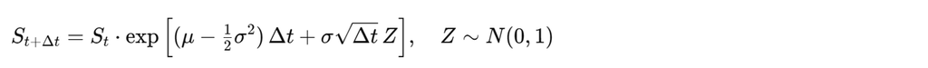

     This method uses the analytical solution of GBM, with no discretization error.
4. **Statistical analysis and risk measures:**
   - Value at Risk (VaR):

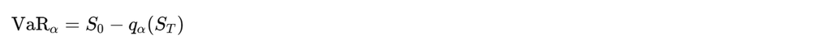

   - Conditional VaR (CVaR):

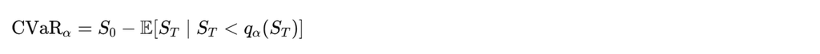

   - Maximum Drawdown (%):

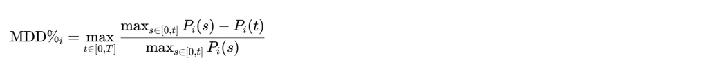

### A. Simulation Setup

In this block, we define the **main parameters** for simulating the S&P 500 price using a Geometric Brownian Motion (GBM) process:

- `T_trading_days`: time horizon in trading days (a typical year).
- `start_date`: start date for downloading the historical series.
- `ticker`: symbol of the asset to analyze (in this case, the S&P 500 from Yahoo Finance).
- `seed`: seed to ensure reproducibility of results.
- `dt`: time step size in days for the simulation.
- `n_trajectories`: number of Monte Carlo trajectories to generate.
- `alpha`: confidence level for calculating **VaR** and **CVaR** (e.g.: 0.01 → 99% confidence).

```python
T_trading_days = 252            # horizon in trading days
start_date = "2020-03-23"       # start date of the historical series
ticker = "^GSPC"                # S&P 500 (Yahoo)
seed = 42                       # reproducible seed (None for random)
dt = 0.05                       # time step size in days
n_trajectories = 1000           # number of Monte Carlo trajectories
alpha = 0.01                    # level for VaR/CVaR
```

### B. Helper Functions for GBM Simulation

This block contains the functions needed to:

- Download historical prices
- Calculate logarithmic returns
- Simulate GBM trajectories
- Obtain statistics and risk measures (VaR, CVaR, Max Drawdown)

```python
def download_close_prices(ticker, start_date, end_date=None):
    """Download adjusted closing prices using yfinance."""
    if end_date is None:
        end_date = datetime.today().strftime("%Y-%m-%d")
    data = yf.download(ticker, start=start_date, end=end_date, progress=False)
    if data.empty:
        raise ValueError("No data obtained for the given ticker/dates.")
    close = data["Close"].dropna()
    return close

def compute_log_returns(prices):
    """Compute logarithmic returns (np.diff on log prices)."""
    log_prices = np.log(prices)
    log_returns = log_prices.diff().dropna().values
    return log_returns

def simulate_gbm_exact(S0, mu, sigma, dt, n_steps, n_trajectories, rng):
    """
    Vectorized GBM simulation using the exact solution:
    S_{t+dt} = S_t * exp( (mu - 0.5*sigma^2) * dt + sigma * sqrt(dt) * Z )
    Returns array with shape (n_trajectories, n_steps+1)
    """
    shape = (n_trajectories, n_steps)
    Z = rng.normal(size=shape)
    increments = (mu - 0.5 * sigma**2) * dt + sigma * np.sqrt(dt) * Z
    # Cumulative along rows:
    log_increments = np.cumsum(increments, axis=1)
    log_paths = np.hstack((np.zeros((n_trajectories, 1)), log_increments))
    S_paths = S0 * np.exp(log_paths)
    return S_paths

def descriptive_statistics(flat_prices):
    """Returns a dict with statistics over a price vector."""
    return {
        "mean": float(np.mean(flat_prices)),
        "range": float(np.max(flat_prices) - np.min(flat_prices)),
        "variance": float(np.var(flat_prices)),
        "std_dev": float(np.std(flat_prices)),
        "skewness": float(skew(flat_prices)),
        "kurtosis": float(kurtosis(flat_prices))
    }

def VaR_from_simulation(final_prices, S0, alpha=0.01):
    """Simple VaR: S0 - quantile_alpha(final_prices)"""
    q = np.quantile(final_prices, alpha)
    VaR = float(S0 - q)
    return VaR

def CVaR_from_simulation(final_prices, S0, alpha=0.01):
    """CVaR (Expected Shortfall): average of outcomes below the alpha quantile"""
    q = np.quantile(final_prices, alpha)
    tail = final_prices[final_prices < q]
    if tail.size == 0:
        return float(S0 - q)  # fallback
    cvar = float(S0 - np.mean(tail))
    return cvar

def max_drawdown_each_path(paths):
    """
    Calculate Maximum Drawdown for each trajectory.
    paths: array with shape (n_traj, n_steps+1)
    returns: array of max drawdown per trajectory
    """
    peaks = np.maximum.accumulate(paths, axis=1)
    drawdowns = peaks - paths  # absolute drop
    max_drawdowns = np.max(drawdowns, axis=1)
    return max_drawdowns
```

### 1. Reproducibility and Data Download

We initialize a reproducible random number generator (`rng`) and download the **historical closing prices (adjusted)** of the S&P 500, displaying the most recent price.

```python
# Reproducibility
rng = np.random.default_rng(seed)

# Download historical data of the asset
close_prices = download_close_prices(ticker, start_date)
S0 = float(close_prices.iloc[-1])  # Most recent price

print(f"Latest S&P 500 price: {S0:.2f} (date: {close_prices.index[-1].date()})\n")
```

```
Latest S&P 500 price: 6699.40 (date: 2025-10-22)
```

### 2. Calculation of Logarithmic Returns and Historical Parameters

We calculate the asset's **logarithmic returns** and estimate the historical parameters: drift (μ) and volatility (σ), displaying the results in a simple DataFrame.

```python
# Logarithmic returns
log_returns = compute_log_returns(close_prices)
mu = float(np.mean(log_returns))            # Estimated drift
sigma = float(np.std(log_returns, ddof=0))  # Historical volatility

# Create simple DataFrame
params_df = pd.DataFrame({
    "Drift (μ)": [mu],
    "Volatility (σ)": [sigma]
}, index=["S&P 500"])

# Round and display
params_df = params_df.round(6)
display(params_df)
```

|  | Drift (μ) | Volatility (σ) |
| --- | --- | --- |
| S&P 500 | 0.000781 | 0.011746 |

### 3. Time Grid Construction and Trajectory Simulation

We define the **time grid** for the simulation and generate the **GBM trajectories** using the exact solution method.

```python
# Time grid
n_steps = int(np.ceil(T_trading_days / dt))
time_grid = np.linspace(0, T_trading_days, n_steps + 1)

# Trajectories with the selected method
paths = simulate_gbm_exact(S0, mu, sigma, dt, n_steps, n_trajectories, rng)

print(f"Simulation completed: {n_trajectories} trajectories generated using the exact method.")
```

```
Simulation completed: 1000 trajectories generated using the exact method.
```

### 4. Descriptive Statistics of Simulated Prices

We flatten all simulated trajectories to calculate **descriptive statistics** of the prices, displaying them in an organized and rounded DataFrame.

```python
# Flatten prices and calculate statistics
prices_flat = paths.flatten()
statistics = descriptive_statistics(prices_flat)

# Create DataFrame directly with final column names
df_desc = pd.DataFrame([{
    "Mean": statistics["mean"],
    "Range": statistics["range"],
    "Variance": statistics["variance"],
    "Std_Dev": statistics["std_dev"],
    "Skewness": statistics["skewness"],
    "Kurtosis": statistics["kurtosis"]
}], index=["S&P 500"]).round(4)

# Display results
print("\nDescriptive statistics (simulated):")
display(df_desc)
```

```
Descriptive statistics (simulated):
```

|  | Mean | Range | Variance | Std_Dev | Skewness | Kurtosis |
| --- | --- | --- | --- | --- | --- | --- |
| S&P 500 | 7460.3066 | 13602.7955 | 1.253236e+06 | 1119.4802 | 1.0633 | 2.502 |

### 5. Risk Measures: VaR, CVaR, and Maximum Drawdown

We calculate the asset's **risk measures** from the final trajectories: VaR, CVaR, and Maximum Drawdown, displaying them in a formatted DataFrame for clarity.

```python
# Calculate final prices and max drawdowns
final_prices = paths[:, -1]
max_dds = max_drawdown_each_path(paths)
max_dd = float(np.max(max_dds))

# Create DataFrame containing risk measures
risk_df = pd.DataFrame({
     "VaR": [round(VaR_from_simulation(final_prices, S0, alpha=alpha), 2)],
     "CVaR": [round(CVaR_from_simulation(final_prices, S0, alpha=alpha), 2)],
     "Max Drawdown": [round(max_dd, 2)],
     "Max Drawdown (%)": [round(np.max(max_dds / np.max(paths, axis=1)) * 100, 2)]},
      index=["S&P 500"]).round(4)

VaR = risk_df.loc["S&P 500", "VaR"]
CVaR = risk_df.loc["S&P 500", "CVaR"]
Max_Drawdown = risk_df.loc["S&P 500", "Max Drawdown"]

print(f"\nRisk measures (confidence level = {(1 - alpha) * 100:.0f}%):")
display(risk_df)
```

```
Risk measures (confidence level = 99%):
```

|  | VaR | CVaR | Max Drawdown | Max Drawdown (%) |
| --- | --- | --- | --- | --- |
| S&P 500 | 1700.19 | 2093.53 | 3478.29 | 48.71 |

## 6. Visualization of Trajectories and Risk Distributions

Together, these visualizations help understand both the **simulated price behavior** and the **risks associated with extreme drops**.

```
Generating plots...
```

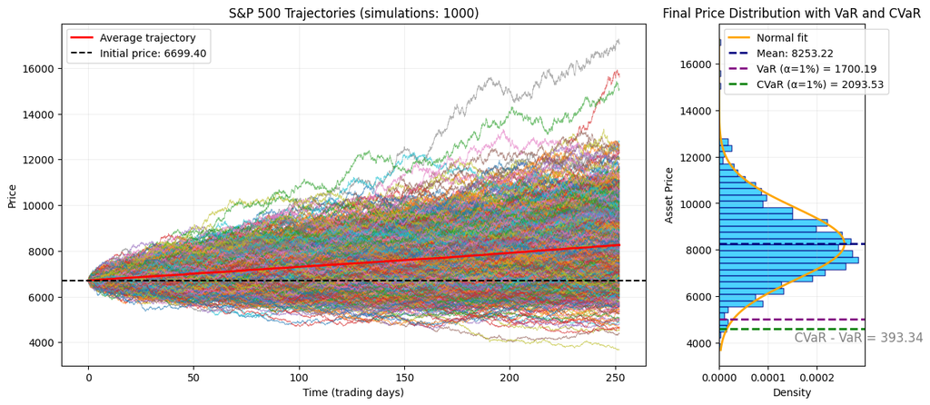

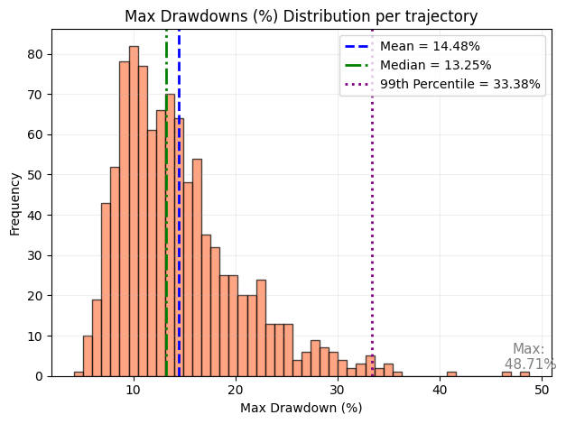

```python
print("Generating plots...")

# Main panel: trajectories + final distribution
fig, axs = plt.subplots(1, 2, figsize=(14, 6), gridspec_kw={'width_ratios': [4, 1]})

# (a) Simulated trajectories
for i in range(min(n_trajectories, 1000)):
    axs[0].plot(time_grid, paths[i, :], linewidth=0.6, alpha=0.6)

avg_traj = np.mean(paths, axis=0)
axs[0].plot(time_grid, avg_traj, color="red", linewidth=2.0, label="Average trajectory")
axs[0].axhline(S0, color="black", linestyle="--", linewidth=1.5, label=f"Initial price: {S0:.2f}")

axs[0].set_title(f"S&P 500 Trajectories (simulations: {n_trajectories})")
axs[0].set_xlabel("Time (trading days)")
axs[0].set_ylabel("Price")
axs[0].legend()
axs[0].grid(alpha=0.2)

# (b) Final price distribution with VaR, CVaR and Max Drawdown
mup, sigmap = norm.fit(final_prices)
x = np.linspace(final_prices.min(), final_prices.max(), 1000)
p = norm.pdf(x, mup, sigmap)

axs[1].hist(final_prices, bins=50, density=True, orientation='horizontal',
            color='deepskyblue', edgecolor='navy', alpha=0.7)
axs[1].plot(p, x, linewidth=2.0, color='orange', label='Normal fit')

axs[1].axhline(mup, color='navy', linestyle='--', linewidth=2, label=f"Mean: {mup:.2f}")
axs[1].axhline(S0 - VaR, color='purple', linestyle='--', linewidth=2,
               label=f"VaR (α={alpha*100:.0f}%) = {VaR:.2f}")
axs[1].axhline(S0 - CVaR, color='green', linestyle='--', linewidth=2,
               label=f"CVaR (α={alpha*100:.0f}%) = {CVaR:.2f}")

diff = CVaR - VaR
y_min = final_prices.min()
axs[1].text(max(p)*0.6, y_min + (mup - y_min)*0.05,
            f"CVaR - VaR = {diff:.2f}", fontsize=12, color='grey', verticalalignment='bottom')

axs[1].set_title("Final Price Distribution with VaR and CVaR")
axs[1].set_xlabel("Density")
axs[1].set_ylabel("Asset Price")
axs[1].legend()
axs[1].grid(alpha=0.2)

plt.show()

# (c) Max Drawdowns (%) distribution
print('\n')
max_dds_pct = (max_dds / np.max(paths, axis=1)) * 100  # normalize by the maximum of each trajectory

counts, bins, _ = plt.hist(max_dds_pct, bins=50, color='coral', edgecolor='black', alpha=0.7)

plt.title("Max Drawdowns (%) Distribution per trajectory")
plt.xlabel("Max Drawdown (%)")
plt.ylabel("Frequency")
plt.grid(alpha=0.2)

mean_dd = np.mean(max_dds_pct)
median_dd = np.median(max_dds_pct)
p99_dd = np.percentile(max_dds_pct, 99)
max_dd = np.max(max_dds_pct)

plt.axvline(mean_dd, color='blue', linestyle='--', linewidth=2, label=f"Mean = {mean_dd:.2f}%")
plt.axvline(median_dd, color='green', linestyle='-.', linewidth=2, label=f"Median = {median_dd:.2f}%")
plt.axvline(p99_dd, color='purple', linestyle=':', linewidth=2, label=f"99th Percentile = {p99_dd:.2f}%")

# Highlight the maximum Max Drawdown
bin_idx = np.digitize(max_dd, bins) - 1
bin_height = counts[bin_idx] if 0 <= bin_idx < len(counts) else 0

plt.text(max_dd, bin_height + 1, f"Max:\n {max_dd:.2f}%",
         ha='center', va='bottom', fontsize=11, color='grey')

plt.legend()
plt.tight_layout()
plt.show()
```

### References

Wilmott, P. (2006). Paul Wilmott on Quantitative Finance. John Wiley and Sons.

McKiney, W. (2017). Python for Data Analysis. O'Reilly Media.